# Explore_LLCP_2017

Jon Mattes

July 9, 2019

```r
library(readr)
library(dplyr)
library(ggplot2)
library(tidyr)
library(lubridate)
library(ggrepel)
```

Load in necessary files (https://www.cdc.gov/brfss/annual_data/annual_data.htm, https://www.tobaccofreekids.org/assets/factsheets/0097.pdf):

```r
# cigarette taxes by state in 2019
cig_taxes_df <- read_csv('2019_tobacco_taxes_by_state.csv')

# cigarette tax increases by state (2013-2019)
tax_increase_df <- read_csv('cigarette_tax_increases_by_state.csv')

# variable layouts
layout_2017_df <- read_csv('variable_layout_2017.csv')
layout_2016_df <- read_csv('variable_layout_2016.csv')
layout_2015_df <- read_csv('variable_layout_2015.csv')
layout_2014_df <- read_csv('variable_layout_2014.csv')

# BRFSS ASCII files
brfss_2017_df <- read_fwf('LLCP2017ASC/LLCP2017.ASC',
                          fwf_positions(col_names=layout_2017_df$`Variable Name`,
                                        start=layout_2017_df$`Starting Column`,
                                        end=layout_2017_df$`Starting Column` +
                                          layout_2017_df$`Field Length` -
                                          1),
                          guess_max=450000,
                          progress=FALSE)
brfss_2016_df <- read_fwf('LLCP2016ASC/LLCP2016.ASC',
                          fwf_positions(col_names=layout_2016_df$`Variable Name`,
                                        start=layout_2016_df$`Starting Column`,
                                        end=layout_2016_df$`Starting Column` +
                                          layout_2016_df$`Field Length` -
                                          1),
                          guess_max=450000,
                          progress=FALSE)
brfss_2015_df <- read_fwf('LLCP2015ASC/LLCP2015.ASC',
                          fwf_positions(col_names=layout_2015_df$`Variable Name`,
                                        start=layout_2015_df$`Starting Column`,
                                        end=layout_2015_df$`Starting Column` +
                                          layout_2015_df$`Field Length` -
                                          1),
                          guess_max=450000,
                          progress=FALSE)
brfss_2014_df <- read_fwf('LLCP2014ASC/LLCP2014.ASC',
                          fwf_positions(col_names=layout_2014_df$`Variable Name`,
                                        start=layout_2014_df$`Starting Column`,
                                        end=layout_2014_df$`Starting Column` + layout_2014_df$`Field Length` - 1),
                          guess_max=450000,
                          progress=FALSE)
```

Interesting variables available for every year (2017 codebook is available at https://www.cdc.gov/brfss/annual_data/2017/pdf/codebook17_llcp-v2-508.pdf):

- _STATE: Code for each state
- CADULT: Are you 18 years of age or older?
- CHCOCNCR: (Ever told) you had other types of cancer [other than skin]?
- CHCCOPD1: (Ever told) you have chronic obstructive pulmonary disease, C.O.P.D., emphysema or chronic bronchitis?
- SEX: Indicate sex of respondent.
- EDUCA: Code for highest grade or year of school you completed?
- EMPLOY1: Employment status
- INCOME2: Income level
- SMOKE100: Have you smoked at least 100 cigarettes in your entire life?
- SMOKDAY2: Do you now smoke cigarettes every day, some days, or not at all?
- STOPSMK2: During the past 12 months, have you stopped smoking for one day or longer because you were trying to quit smoking?
- LASTSMK2: How long has it been since you last smoked a cigarette, even one or two puffs? (For respondents that claim they do not smoke cigarettes at all now, question SMOKDAY2)
- USENOW3: Do you currently use chewing tobacco, snuff, or snus every day, some days, or not at all?

Create relevant dataframe based on the features identified above:

```r
brfss_2017_cln <- brfss_2017_df %>%
  select(`_STATE`, CHCOCNCR, CHCCOPD1, SEX, EDUCA, EMPLOY1, INCOME2,
         SMOKE100, SMOKDAY2, STOPSMK2, LASTSMK2, USENOW3)
brfss_2016_cln <- brfss_2016_df %>%
  select(`_STATE`, CHCOCNCR, CHCCOPD1, SEX, EDUCA, EMPLOY1, INCOME2,
         SMOKE100, SMOKDAY2, STOPSMK2, LASTSMK2, USENOW3)
brfss_2015_cln <- brfss_2015_df %>%
  select(`_STATE`, CHCOCNCR, CHCCOPD1, SEX, EDUCA, EMPLOY1, INCOME2,
         SMOKE100, SMOKDAY2, STOPSMK2, LASTSMK2, USENOW3)
brfss_2014_cln <- brfss_2014_df %>%
  select(`_STATE`, CHCOCNCR, CHCCOPD1, SEX, EDUCA, EMPLOY1, INCOME2,
         SMOKE100, SMOKDAY2, STOPSMK2, LASTSMK2, USENOW3)
```

Joining brffs_cln tables:

```r
brfss_cln_combo <- rbind(brfss_2017_cln, brfss_2016_cln,
                         brfss_2015_cln, brfss_2014_cln)
```

Summary stats:

```r
summary(cig_taxes_df)
```

```
##       Code          Value                Tax
##  Min.   : 1.00   Length:53          Min.   :0.170
##  1st Qu.:17.00   Class :character   1st Qu.:0.995
##  Median :30.00   Mode  :character   Median :1.700
##  Mean   :30.47                      Mean   :1.915
##  3rd Qu.:44.00                      3rd Qu.:2.700
##  Max.   :72.00                      Max.   :5.100
```

```r
summary(tax_increase_df)
```

```
##       Year         State           Effective Date of Increase
##  Min.   :2013   Length:38          Length:38
##  1st Qu.:2015   Class :character   Class :character
##  Median :2016   Mode  :character   Mode  :character
##  Mean   :2016
##  3rd Qu.:2017
##  Max.   :2019
##  Amount of Increase Tax Rate After Increase
##  Min.   :-0.1000    Min.   :0.675
##  1st Qu.: 0.2050    1st Qu.:1.620
##  Median : 0.3650    Median :2.750
##  Mean   : 0.5284    Mean   :2.604
##  3rd Qu.: 0.7250    3rd Qu.:3.400
##  Max.   : 2.0000    Max.   :5.100
```

```r
summary(brfss_cln_combo)
```

```
##     _STATE             CHCOCNCR        CHCCOPD1          SEX
##  Length:1842439     Min.   :1.000   Min.   :1.000   Min.   :1.000
##  Class :character   1st Qu.:2.000   1st Qu.:2.000   1st Qu.:1.000
##  Mode  :character   Median :2.000   Median :2.000   Median :2.000
##                     Mean   :1.916   Mean   :1.944   Mean   :1.573
##                     3rd Qu.:2.000   3rd Qu.:2.000   3rd Qu.:2.000
##                     Max.   :9.000   Max.   :9.000   Max.   :9.000
##                     NA's   :7       NA's   :13
##      EDUCA          EMPLOY1       INCOME2             SMOKE100
##  Min.   :1.000   Min.   :1.00   Length:1842439     Min.   :1.00
##  1st Qu.:4.000   1st Qu.:1.00   Class :character   1st Qu.:1.00
##  Median :5.000   Median :3.00   Mode  :character   Median :2.00
##  Mean   :4.921   Mean   :3.93                      Mean   :1.61
##  3rd Qu.:6.000   3rd Qu.:7.00                      3rd Qu.:2.00
##  Max.   :9.000   Max.   :9.00                      Max.   :9.00
##  NA's   :1782    NA's   :2496                      NA's   :64145
##     SMOKDAY2          STOPSMK2         LASTSMK2            USENOW3
##  Min.   :1.0       Min.   :1.0       Length:1842439     Min.   :1.00
##  1st Qu.:2.0       1st Qu.:1.0       Class :character   1st Qu.:3.00
##  Median :3.0       Median :1.0       Mode  :character   Median :3.00
##  Mean   :2.4       Mean   :1.5                          Mean   :2.97
##  3rd Qu.:3.0       3rd Qu.:2.0                          3rd Qu.:3.00
##  Max.   :9.0       Max.   :9.0                          Max.   :9.00
##  NA's   :1073215   NA's   :1582337                      NA's   :66425
```

Evaluating distributions:

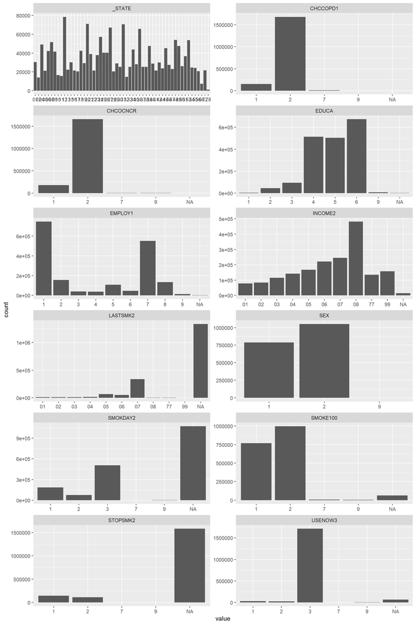

```r
brfss_cln_combo %>%  gather() %>% ggplot(aes(value)) + geom_bar() + facet_wrap(~key, scales='free', ncol=2)
```

Individual graphs for unreadable graphs above:

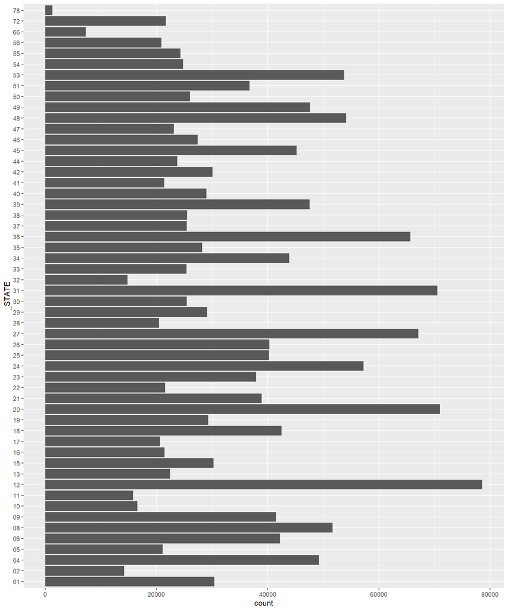

```r
brfss_cln_combo %>% ggplot(aes(`_STATE`)) + geom_bar() + coord_flip()
```

#### Notes from above:

- Will need to remove/impute NA values from several variables
- Number of respondents in each state does not necessarily follow the population distribution. Can easily see that California (06) is not very high compared to their population
- Most respondents have never had COPD
- Most respondents have never had cancer
- The most frequent education level were college graduates, and most of the sample had at least a high school diploma or GED
- Most respondents were employed or retired
- The most common wage was $75,000 or more
- Most responses were NA for LASTSMK2, but for those who were able to respond, their last cigarette was most frequently consumed more than 10 years ago
- 57% of respondents were female
- Most responses were NA for SMOKDAY2, but for those who were able to respond, they most commonly smoke “Not at all”, followed by “Every day”
- 41% of respondents had smoked at least 100 cigarettes in their entire life
- Most responses were NA for STOPSMK2, but for those who were able to respond, they most commonly did try smoking for one day or longer during the past 12 months (57% of those who could answer the question aka smokers)
- Most respondents do not use smokeless tobacco, 3% do use smokeless tobacco

### Cigarette Taxes Around the Country:

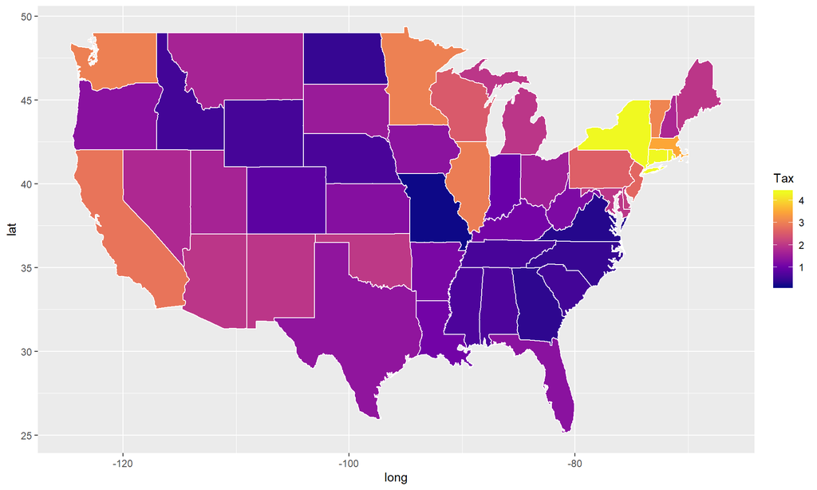

```r
# create relevant table
states_map <- map_data('state')
cig_taxes_df$region <- tolower(cig_taxes_df$Value)
cig_map_df <- left_join(states_map, cig_taxes_df, by='region')

g <- ggplot(cig_map_df, aes(long, lat, group=group)) +
  geom_polygon(aes(fill=Tax), color='white') +
  scale_fill_viridis_c(option='C')
t <- cig_taxes_df %>%
  group_by(Value) %>%
  summarize(`2019 Tax` = mean(Tax)) %>%
  filter(!(Value %in% c('NA', 'Puerto Rico', 'DC', 'Guam'))) %>%
  arrange(desc(`2019 Tax`)) %>%
  mutate(Rank = min_rank(desc(`2019 Tax`))) %>%
  rename(State = Value)

print(g)
```

```r
knitr::kable(t)
```

| State | 2019 Tax | Rank |
| --- | --- | --- |
| Connecticut | 4.350 | 1 |
| New York | 4.350 | 1 |
| Rhode Island | 4.250 | 3 |
| Massachusetts | 3.510 | 4 |
| Hawaii | 3.200 | 5 |
| Vermont | 3.080 | 6 |
| Minnesota | 3.040 | 7 |
| Washington | 3.025 | 8 |
| Illinois | 2.980 | 9 |
| California | 2.870 | 10 |
| New Jersey | 2.700 | 11 |
| Pennsylvania | 2.600 | 12 |
| Wisconsin | 2.520 | 13 |
| Delaware | 2.100 | 14 |
| Oklahoma | 2.030 | 15 |
| Alaska | 2.000 | 16 |
| Arizona | 2.000 | 16 |
| Maine | 2.000 | 16 |
| Maryland | 2.000 | 16 |
| Michigan | 2.000 | 16 |
| New Mexico | 2.000 | 16 |
| Nevada | 1.800 | 22 |
| New Hampshire | 1.780 | 23 |
| Montana | 1.700 | 24 |
| Utah | 1.700 | 24 |
| Ohio | 1.600 | 26 |
| South Dakota | 1.530 | 27 |
| Texas | 1.410 | 28 |
| Iowa | 1.360 | 29 |
| Florida | 1.339 | 30 |
| Oregon | 1.330 | 31 |
| Kansas | 1.290 | 32 |
| West Virginia | 1.200 | 33 |
| Arkansas | 1.150 | 34 |
| Kentucky | 1.100 | 35 |
| Louisiana | 1.080 | 36 |
| Indiana | 0.995 | 37 |
| Colorado | 0.840 | 38 |
| Mississippi | 0.680 | 39 |
| Alabama | 0.675 | 40 |
| Nebraska | 0.640 | 41 |
| Tennessee | 0.620 | 42 |
| Wyoming | 0.600 | 43 |
| Idaho | 0.570 | 44 |
| South Carolina | 0.570 | 44 |
| North Carolina | 0.450 | 46 |
| North Dakota | 0.440 | 47 |
| Georgia | 0.370 | 48 |
| Virginia | 0.300 | 49 |
| Missouri | 0.170 | 50 |

### A History of Tax Increases

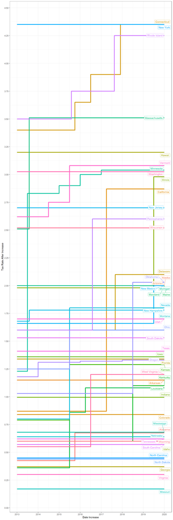

```r
# create 2019 rates
tax_2019_df <- tax_increase_df %>%
  mutate(`Date Increase` = mdy(`Effective Date of Increase`)) %>%
  group_by(State) %>%
  summarize(`Tax Rate After Increase` = max(`Tax Rate After Increase`)) %>%
  mutate(Year = 2019,
         `Effective Date of Increase` = '12/31/2019',
         `Amount of Increase` = 0.0) %>%
  select(Year,
         State,
         `Effective Date of Increase`,
         `Amount of Increase`,
         `Tax Rate After Increase`)

# create 2013 rates
tax_2013_df <- tax_increase_df %>%
  mutate(`Date Increase` = mdy(`Effective Date of Increase`)) %>%
  group_by(State) %>%
  filter(`Tax Rate After Increase` == min(`Tax Rate After Increase`)) %>%
  ungroup() %>%
  mutate(Year = 2013,
         `Effective Date of Increase` = '1/1/2013',
         `Tax Rate After Increase` = `Tax Rate After Increase` - `Amount of Increase`,
         `Amount of Increase` = 0.0) %>%
  select(Year,
         State,
         `Effective Date of Increase`,
         `Amount of Increase`,
         `Tax Rate After Increase`)

# add 2013 and 2019 values for states not in tax_increase_df
flat_tax_2013 <- cig_taxes_df %>%
  anti_join(tax_increase_df, by=c('Value' = 'State')) %>%
  mutate(Year = 2013,
         `Effective Date of Increase` = '1/1/2013',
         `Tax Rate After Increase` = Tax,
         `Amount of Increase` = 0.0,
         State = Value) %>%
  select(Year,
         State,
         `Effective Date of Increase`,
         `Amount of Increase`,
         `Tax Rate After Increase`)
flat_tax_2019  <- flat_tax_2013 %>%
  mutate(Year = 2019,
         `Effective Date of Increase` = '12/31/2019')

# combine all dataframes
tax_increase_combo <- rbind(tax_2019_df, tax_increase_df, tax_2013_df,
                            flat_tax_2013, flat_tax_2019) %>%
  filter(!(State %in% c('NA', 'Puerto Rico', 'Washington, DC', 'Guam',
                        'Northern Mariana Isl.', 'DC')))

# create graph
g <- tax_increase_combo %>%
  mutate(`Date Increase` = mdy(`Effective Date of Increase`),
         label = if_else(`Date Increase` == max(`Date Increase`), as.character(State), NA_character_)) %>%
  ggplot(aes(x=`Date Increase`, y=`Tax Rate After Increase`, group=State, color=State)) +
  theme_bw() +
  geom_step(size=1.5) +
  geom_label_repel(aes(label=label), nudge_x=1, na.rm =TRUE) +
  theme(legend.position='none')  +
  scale_y_continuous(breaks=seq(0, 5.25, 0.25)) +
  scale_x_date(date_breaks='1 year', date_labels='%Y')

# create table
t <- tax_increase_df

print(g)
```

```r
knitr::kable(t)
```

[output not shown]

### Smoking Rates Around the Country

```r
# going to look at SMOKE100, SMOKDAY2, STOPSMK2, LASTSMK2 AND USENOW3
```

Notes: -Missing information on smokers < 18 years old. Not in this survey. -Individual taxes for specific regions may be different based on county or city taxes.